# Sprawozdanie 3

Karol Szpyt, Przemysław Wojtarowicz

23 maja 2018

# Wstęp

Sprawozdanie ma za zadanie ukazać zależność spalania samochodów w zależności od innych czynników oraz różnice między klasycznymi metodamy ekonometrycznymi oraz metodamy bootstrapowymi. W tym celu przedstawione zostaną statystyki opisowe oraz zbudowany zostanie model liniowy, na podstawie których wyciągane będą wnioski.

# Użyte bibioteki

```r
library(ggplot2)
library(knitr)
library(units)
library(tseries)
library(lmtest)
library(tidyr)
library(dplyr)
```

## Dane

Przy pomocy pakietu *units* jednostki zmiennych zamienione zostały na europejskie standardy

```r
N <- 10^5
dane$mpg <- set_units(dane$mpg, mile/gallon)
units(dane$mpg) <- with(ud_units, l/km)
dane$mpg <- as.numeric(dane$mpg) * 100
dane$mpg <- format(round(dane$mpg, 2))

dane$displacement <- set_units(dane$displacement, inch^3)
units(dane$displacement) <- with(ud_units, l)

dane$weight <- set_units(dane$weight, pound)
units(dane$weight) <- with(ud_units, kg)

dane$acceleration <- set_units(dane$acceleration, second)

dane$mpg <- as.numeric(dane$mpg)
colnames(dane)[1] <- "lp100km"
```

Pierwsze 10 pozycji danych

| X | lp100km | cylinders | displacement | horsepower | weight | acceleration | year | origin | name |
| --- | --- | --- | --- | --- | --- | --- | --- | --- | --- |
| 1 | 9.80 | 4 | 1.474836 | 75 | 956.1727 | 15.5 | 74 | 2 | fiat 128 |
| 2 | 11.20 | 6 | 3.277413 | 85 | 1173.4435 | 16.0 | 70 | 1 | ford maverick |
| 3 | 7.47 | 4 | 1.458449 | 71 | 902.6488 | 14.9 | 78 | 2 | volkswagen scirocco |
| 4 | 12.12 | 6 | 3.801799 | 90 | 1456.0315 | 17.2 | 78 | 1 | amc concord |
| 5 | 13.07 | 6 | 3.687089 | 105 | 1415.6618 | 16.5 | 73 | 1 | plymouth valiant |
| 6 | 8.11 | 4 | 1.114320 | 49 | 846.8570 | 19.5 | 73 | 2 | fiat 128 |
| 7 | 12.38 | 6 | 3.687089 | 100 | 1646.5403 | 17.7 | 77 | 1 | plymouth volare custom |
| 8 | 9.05 | 4 | 1.999222 | 80 | 1111.7549 | 16.5 | 74 | 1 | ford pinto |
| 9 | 7.71 | 4 | 1.589545 | 78 | 993.3673 | 14.1 | 77 | 2 | volkswagen dasher |
| 10 | 14.26 | 6 | 2.753027 | 120 | 1732.7229 | 16.7 | 76 | 2 | mercedes-benz 280s |

Objaśnienie zmiennych

- lp100km- spalanie w litrach na 100km.
- cylinders- liczba cylindrów.
- displacement- objętość silnika litrach.
- horsepower- moc w koniach mechanicznych.
- weight- waga w kilogramach.
- acceleration- czas przyspieszenia od 0 do 100 km/h, podany w sekundach.
- year- rok produkcji.
- origin- miejsce produkcji (1- USA, 2- Europa, 3- Japonia).
- name- nazwa samochodu.

Na samym początku usunięte zostaną z danych zmienne jakościowe tj. **origin** oraz **name**, nie będą one brane pod uwagę w dalszej części projektu.

Poniżej obliczony zostanie współczynnik zmienności.  
Współczynnik obliczany jest ze wzoru: $\frac{sd}{mean}$

Współczynnik zmienności dla poszczególnych zmiennych

|  | value |
| --- | --- |
| lp100km | 0.3483811 |
| cylinders | 0.3116590 |
| displacement | 0.5405405 |
| horsepower | 0.3647049 |
| weight | 0.2889957 |
| acceleration | 0.1765575 |
| year | 0.0477416 |

Jak widać w powyższej tabeli zmienna **year** ma bardzo niską wartość liczonego współczynnika (mniej niż 10%) więc w kolejnych obliczeniach będzie ona pomijana

## Dobieranie zmiennych metodą Hellwiga

Funkcja odpowiedzialna za metodę Hellwiga

```r
hellwig <- function(y, x)
{
  n <- ncol(x)
  l <- (2^n)-1
  R0 <- cor(y, x)
  R <- abs(as.matrix(cor(x)))
  argument <- replicate(n, c(0, 1), simplify = FALSE)
  comb <- as.matrix(expand.grid(argument))
  comb <- comb[-1,]
  h <- matrix(0, l, n)
  for(i in 1:l)
  {
    for(j in 1:n)
    {
      h[i,j] <- (comb[i, j] * (R0[j]^2))/ (comb[i,] %*% as.vector(R[,j]))
    }
  }
  m=which.max(rowSums(h))
  colnames(comb) <- colnames(x)
  return((comb[m,]))
}
```

Wynik powyżeszj funkcji wskaże zmienne które będą najlepsze do wykorzystania w modelu liniowym.

Output dla metody Hellwiga

|  | value |
| --- | --- |
| cylinders | 0 |
| displacement | 0 |
| horsepower | 1 |
| weight | 1 |
| acceleration | 0 |

Jak widać metoda Hellwiga wskazała, że najlepsze będą zmienne **horsepower** oraz **weight**.  
To właśnie te zmienne zastosowane zostaną w modelu jako zmienne objaśniająće.

## Dobieranie zmiennych metodą bootstrapową

Funkcje odpowiedzialną za dobieranie zmiennych metodą bootstrapową

```r
boot_coef <- function(dane)
{
    boot_sample <- sample(1:nrow(dane),
                          nrow(dane),
                          replace = T)
    model <- lm(lp100km ~ ., data = dane[boot_sample, ])
    return(coef(model))
}
bootstrap <- function(dane, alpha = 0.05, n = 10^4)
{
  coefs <- sapply(rep(1, n), function(x) boot_coef(dane))
  conf_inter <- apply(coefs, 1, function(x) quantile(x, c(alpha/2, 1-alpha/2)) )

  pvec<- data.frame("const" = NA, "cylinders" = NA, "displacement" = NA, "horsepower" = NA, "weight" = NA, "accelaration" = NA)

  coefs <- t(coefs)
  for(i in 1:ncol(conf_inter))
  {
    if(mean(conf_inter[1,i], conf_inter[2,i]) > 0)
    {
      pvec[, i] <- length(coefs[coefs[, i] <0 , i]) / n
    }
    else
    {
      pvec[, i] <- length(coefs[coefs[, i] > 0, i]) / n
    }
  }
  index <- 0
  pvec <- as.numeric(pvec[, -1])
  index <- which(pvec > alpha)

  #index <- which(pvec[index == max(pvec)])
  if(length(index) != 0)
  {
      index <- which(pvec == max(pvec, na.rm = TRUE))
      dane <- dane[, -(index + 1)]
      bootstrap(dane, alpha, n)
  }
  else
  {
    return(dane)
  }
}
```

Outputem dla metody bootsrapowej jest gotowa ramka danych, gdzie pierwsza zmienna jes zmienną objaśnianą, a reszta zmiennych to zmienne objaśniające.

Pierwsze 6 obserwacji gotowej tabeli

| lp100km | horsepower | weight |
| --- | --- | --- |
| 9.80 | 75 | 956.1727 |
| 11.20 | 85 | 1173.4435 |
| 7.47 | 71 | 902.6488 |
| 12.12 | 90 | 1456.0315 |
| 13.07 | 105 | 1415.6618 |
| 8.11 | 49 | 846.8570 |

Jak widać metoda ta również wskazała, że najlepsze do wykorzystania w modelu będą zmienne **horsepower** oraz **weight**.

## Hipotezy

Spodziewać się można, że wzrost zarówno **mocy** auta jak i jego **wagi** zwiększać będzie **spalanie**.

# Wizualizacja zależności między wybranymi zmiennymi

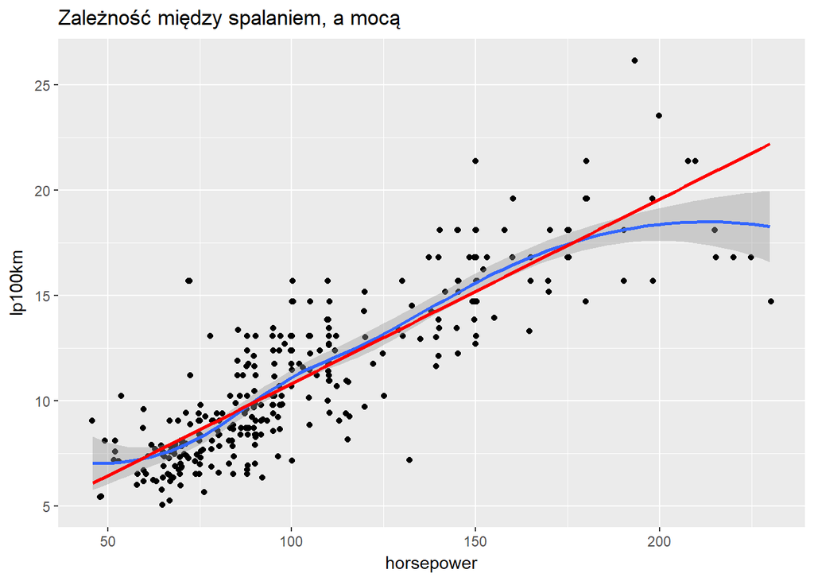

[figure not shown]

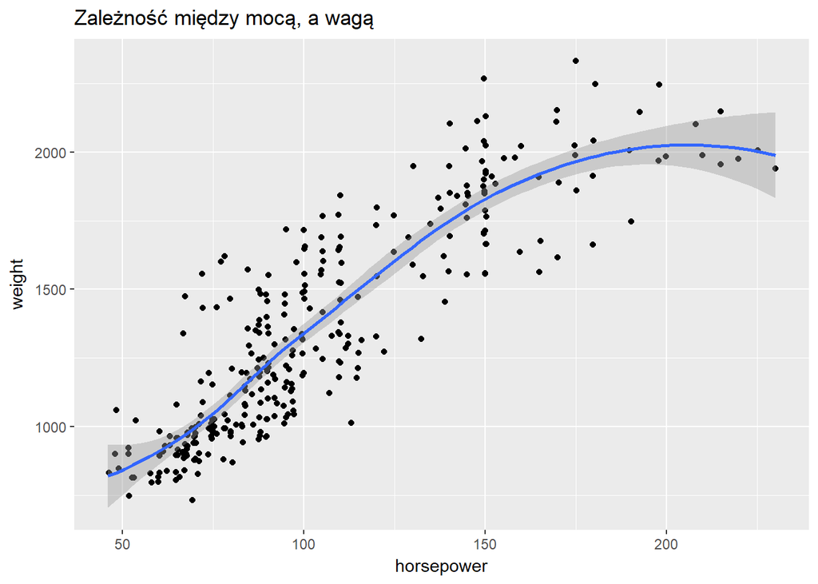

Trzeba zauważyć, że pomiędzy zmiennymi objaśniającymi występuje silna korelacja

```r
cor(dane$horsepower, dane$weight)
```

```
## [1] 0.8697402
```

# Model liniowy

```r
model <- lm(lp100km ~ horsepower + weight, dane)
```

[output not shown]

### Badanie normalności reszt za pomocą testu Jarque Bera

```r
jarque.bera.test(model$residuals)
```

```
##
##  Jarque Bera Test
##
## data:  model$residuals
## X-squared = 47.148, df = 2, p-value = 5.78e-11
```

Test Jarque Bera wskazał bardzo niską wartośc p-value co oznacza, że reszty **nie** mają rozkładu normalnego.

### Badanie współczynnika determinacji

```
## [1] 0.823086
```

Współczynnik determinacji wynosi ponad **80%** co jest bardzo dobrym wynikiem. Współczynnik ten informuje o tym, jaka część zmienności zmiennej objaśnianej została wyjaśniona przez model. Jest on więc miarą stopnia, w jakim model wyjaśnia kształtowanie się zmiennej objaśnianej.

### Badanie heteroskedastyczności

Test Breuscha-Pagana

```r
bptest(model)
```

```
##
##  studentized Breusch-Pagan test
##
## data:  model
## BP = 15.445, df = 2, p-value = 0.0004428
```

P-value jest mniejsze od domyślnego 5% co oznacza, że odrzucana jest hipoteza zerowa - w modelu **występuje** heteroskedastyczność.

### Badanie poprawności specyfikacji dla modeli regresji liniowej

Test RESET Ramseya. Test stosowany jest w celu sprawdzenia, czy to liniowa postać modelu jest najlepszym możliwym do wybrania modelem.

```r
resettest(model, power=2, type="regressor")
```

```
##
##  RESET test
##
## data:  model
## RESET = 1.7425, df1 = 2, df2 = 309, p-value = 0.1768
```

P-value jest większe od domyślnego 5% co oznacza, że nie ma przesłanek do odrzucenia H0 - postać modelu **jest dobra**.

## Postać modelu

```r
model$coefficients
```

```
##  (Intercept)   horsepower       weight
## -0.555086708  0.031968756  0.006248746
```

$$Y = -0.5551 + 0.0319X1 + 0.0062X2$$

Hipoteza potwierdziła się. Korzystając z zasady *ceteris paribus* zwiększająca się liczba koni mechanicznych zwiększa spalanie w przybliżeniu o 0.03 $\frac{l}{100km}$, a wzrost wagi (kg) implikuje wzrost spalanie o około 0.006 $\frac{l}{100km}$

### Przedziały ufności dla współczynników metodą klasyczną

Przedziały ufności dla współczynnika zmiennej horsepower

|  | lewy koniec przedziału | prawy koniec przedziału |
| --- | --- | --- |
| 90% | 0.0238500 | 0.0400875 |
| 95% | 0.0222946 | 0.0416429 |
| 99% | 0.0192548 | 0.0446827 |

Przedziały ufności dla współczynnika zmiennej weight

|  | lewy koniec przedziału | prawy koniec przedziału |
| --- | --- | --- |
| 90% | 0.0054544 | 0.0070431 |
| 95% | 0.0053022 | 0.0071953 |
| 99% | 0.0050048 | 0.0074927 |

### Przedziały ufności dla współczynników metodą bootstrapową

Przedziały ufności dla współczynnika zmiennej horsepower

|  | lewy koniec przedziału | prawy koniec przedziału |
| --- | --- | --- |
| 90% | 0.0203465 | 0.0445070 |
| 95% | 0.0182532 | 0.0470195 |
| 99% | 0.0139231 | 0.0518179 |

Przedziały ufności dla współczynnika zmiennej weight

|  | lewy koniec przedziału | prawy koniec przedziału |
| --- | --- | --- |
| 90% | 0.0052278 | 0.0072280 |
| 95% | 0.0050291 | 0.0074096 |
| 99% | 0.0046336 | 0.0077681 |

Możliwe jest zaobserowwanie lekkich różnic pomiędzy przedziałąmi ufności wyznaczonymi metodą bootstrapową. Należy jednak pamiętać, że reszty w modelu klasycznym nie miały rozkładu normalnego przez co przedziały wyznaczone za pomocą metody klasycznej mogą być zakłamane.

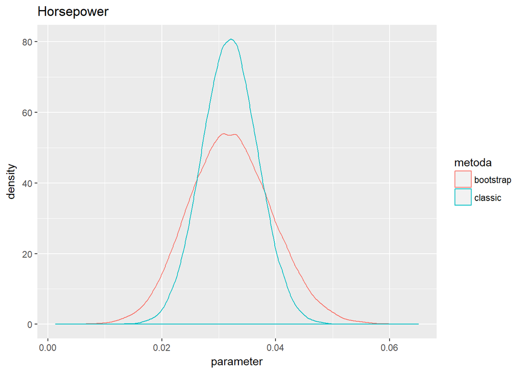

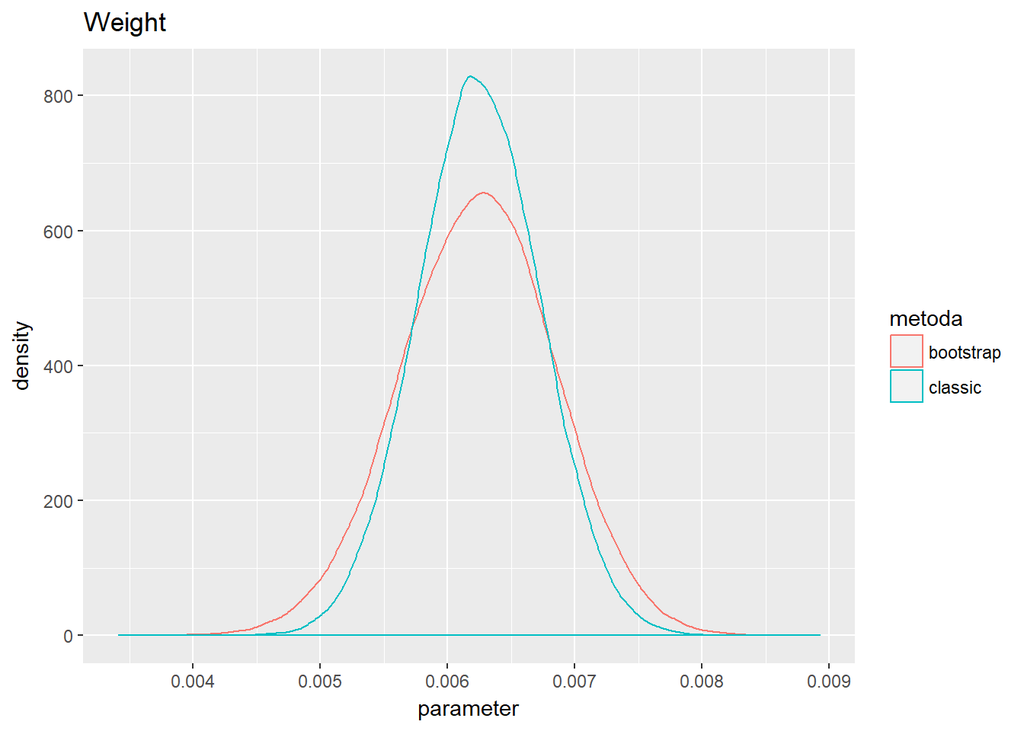